# Project: Word Cloud with Python

This is a small project for creating a word cloud using python and it's libraries. Here we take some data from WHO's site for corona virus updates and count for how many times each word appeared in it, and then make a simple word cloud with those word counts.

## I am going to use the following libraries of Pythoh

### To install them you can use

```python
!pip install wordcloud
!pip install fileupload
!pip install ipywidgets
!jupyter nbextension install --py --user fileupload
!jupyter nbextension enable --py fileupload
```

[output not shown]

#### Whoa!! all my requirements are satisfied

## Let's get started with importing all the libraries

```python
import wordcloud
import numpy as np
from matplotlib import pyplot as plt
from IPython.display import display
import fileupload
import io
import sys
```

To upload your text file, run the following cell that contains all the code for a custom uploader widget. Once you run this cell, a "Browse" button should appear below it. Click this button and navigate the window to locate your saved text file.

```python
# This is the uploader widget
def _upload():

    _upload_widget = fileupload.FileUploadWidget()

    def _cb(change):
        global file_contents
        decoded = io.StringIO(change['owner'].data.decode('utf-8'))
        filename = change['owner'].filename
        print('Uploaded `{}` ({:.2f} kB)'.format(
            filename, len(decoded.read()) / 2 **10))
        file_contents = decoded.getvalue()

    _upload_widget.observe(_cb, names='data')
    display(_upload_widget)

_upload()
```

```
Uploaded `corona_file.txt` (5.03 kB)
```

The uploader widget saved the contents of your uploaded file into a string object named file_contents that your word cloud script can process. This was a lot of preliminary work.

```python
def calculate_frequencies(file_contents):
    # Here is a list of punctuations and uninteresting words you can use to process your text
    punctuations = '''!()-[]{};:'"\,<>./?@#$%^&*_~'''
    uninteresting_words = ["the", "a", "to", "if", "is", "it", "of", "and", "or", "an", "as", "i", "me", "my", \
    "we", "our", "ours", "you", "your", "yours", "he", "she", "him", "his", "her", "hers", "its", "they", "them", \
    "their", "what", "which", "who", "whom", "this", "that", "am", "are", "was", "were", "be", "been", "being", \
    "have", "has", "had", "do", "does", "did", "but", "at", "by", "with", "from", "here", "when", "where", "how", \
    "all", "any", "both", "each", "few", "more", "some", "such", "no", "nor", "too", "very", "can", "will", "just"]

    list_of_words = file_contents.split()
    updated_list_of_words = []

    # removing the punctuations and putting every word into lowercase
    for text in list_of_words:
        if text.isalpha() == False:
            for indiv_punctuations in punctuations:
                text = text.replace(indiv_punctuations, "")
        lowercase_text = text.lower()
        updated_list_of_words.append(lowercase_text)

    # removing the uninteresting words from the updated list we created above
    removed_uninteresting_words = []
    for text in updated_list_of_words:
        if text not in uninteresting_words:
            removed_uninteresting_words.append(text)

    #creating new dictionary and adding texts to it
    new_dict = {}
    for text in removed_uninteresting_words:
        if text not in new_dict: #check if text exist in dict
            new_dict[text] = 1
        else: #else increment value by 1
            new_dict[text] +=1

    #wordcloud library
    cloud = wordcloud.WordCloud()
    cloud.generate_from_frequencies(new_dict)
    return cloud.to_array()
```

#### fingers crossed!!!

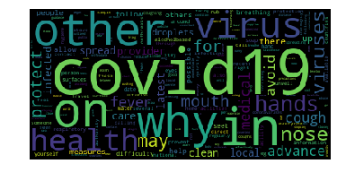

```python
# Display your wordcloud image
myimage = calculate_frequencies(file_contents)
plt.imshow(myimage, interpolation = 'nearest')
plt.axis('off')
plt.show()
```